[목차](https://waterfirst.github.io/insight-lab/)

# 인구 감소의 물리학 — 한국 출산율은 감쇠 조화 진동자다

Insight Lab Special #5 | 사회학 × 물리학

저자

Nakcho Choi × Claude Opus 4.6

공개

2026년 4월 24일

**코드 보기**

```r
library(ggplot2)
library(dplyr)
library(tidyr)
library(patchwork)
library(scales)
library(showtext)
library(ggtext)
library(forcats)

font_add_google("Noto Sans KR", "notosanskr")
showtext_auto()

theme_insight <- function(base_size = 13) {
  theme_minimal(base_size = base_size, base_family = "notosanskr") +
    theme(
      plot.title = element_text(face = "bold", size = rel(1.3), margin = margin(b = 8)),
      plot.subtitle = element_markdown(color = "grey40", size = rel(0.9), margin = margin(b = 12)),
      panel.grid.minor = element_blank(),
      panel.grid.major = element_line(color = "grey92"),
      legend.position = "bottom",
      axis.title = element_text(size = rel(0.9), color = "grey30"),
      plot.caption = element_text(color = "grey50", size = rel(0.7), hjust = 0),
      plot.margin = margin(15, 15, 15, 15)
    )
}

pal <- list(
  red = "#E63946", blue = "#457B9D", green = "#2A9D8F",
  orange = "#E9C46A", dark = "#1D3557", purple = "#6C5B7B"
)
```

## 프롤로그: “번식을 거부하는 종”이라는 물리학적 이상 현상

> “어떤 시스템이든 평형에서 벗어나면, 복원력이 작용한다. 문제는 그 복원력이 충분한가이다.” — 자유 해석

다윈의 진화론에서 가장 설명하기 어려운 현상이 하나 있다. **번식을 자발적으로 거부하는 종**의 출현이다. 자연선택의 논리에 의하면, 번식을 거부하는 유전자는 다음 세대에 전달되지 못하므로 즉시 도태되어야 한다. 그런데 한국에서는 이 “도태되어야 할 행동”이 **사회 전체로 확산**되고 있다.

2023년, 한국의 합계출산율은 **0.72명**을 기록했다. 세계 꼴찌. 인류 역사상 전쟁이나 기근 없이 이 수준까지 떨어진 나라는 없다.

그런데 2024년 **0.75명**, 2025년 **0.80명**으로 반등했다. 9년 만의 전환.

이 에세이는 묻는다: **이 반등은 “복원력”인가, “잡음”인가?**

물리학의 **감쇠 조화 진동자(Damped Harmonic Oscillator)** 모델을 사회 현상에 적용하여, 한국 출산율의 과거·현재·미래를 해석한다.

## I. 모델: 출산율 = 감쇠 진동자

### 물리학에서 빌려온 프레임

질량이 스프링에 달려 있고, 마찰이 있는 시스템. 진동하면서 점점 평형으로 수렴한다. 한국 출산율을 56년치 데이터(1970-2025)에 피팅하면, 놀랍게도 이 모델이 잘 맞는다.

$$\text{TFR}(t) = \underbrace{\text{TFR}_{eq}}_{\text{평형}} + \underbrace{A_1 e^{-\gamma_1 t}}_{\text{산업화 감쇠}} + \underbrace{A_2 e^{-\gamma_2 t} \cos(\omega t + \phi)}_{\text{세대 진동}}$$

**코드 보기**

```r
df <- tibble(
  year = 1970:2025,
  tfr = c(
    4.53, 4.54, 4.12, 4.07, 3.77, 3.43, 3.00, 2.99, 2.64, 2.90,
    2.82, 2.57, 2.39, 2.06, 1.74, 1.66, 1.58, 1.53, 1.55, 1.56,
    1.57, 1.71, 1.76, 1.65, 1.66, 1.63, 1.57, 1.52, 1.45, 1.41,
    1.48, 1.31, 1.18, 1.19, 1.16, 1.09, 1.13, 1.26, 1.19, 1.15,
    1.23, 1.24, 1.30, 1.19, 1.21, 1.24, 1.17, 1.05, 0.98, 0.92,
    0.84, 0.81, 0.78, 0.72, 0.75, 0.80
  )
) |> mutate(t = year - 1970)

fit <- nls(
  tfr ~ eq + A1 * exp(-g1 * t) + A2 * exp(-g2 * t) * cos(w * t + phi),
  data = df,
  start = list(eq = 1.028, A1 = 3.702, g1 = 0.0909, A2 = -0.184, g2 = 0.001, w = 0.346, phi = 0.748),
  control = nls.control(maxiter = 5000, tol = 1e-5, warnOnly = TRUE),
  algorithm = "port",
  lower = c(0.0, 0.5, 0.01, -3, 0.0, 0.05, -pi),
  upper = c(1.8, 7.0, 0.30, 3, 0.20, 1.5, pi)
)

p <- coef(fit)
period_yr <- 2 * pi / p["w"]
half_life <- log(2) / p["g1"]
```

### 피팅 결과: 56년을 7개 파라미터로

**코드 보기**

```r
tibble(
  `물리량` = c("TFR_eq (장기 평형)", "A1 (산업화 진폭)", "gamma1 (산업화 감쇠율)",
              "거시 반감기", "A2 (진동 진폭)", "omega (각진동수)",
              "T (진동 주기)", "RMSE"),
  `값` = c(sprintf("%.2f명", p["eq"]), sprintf("%.2f", p["A1"]),
          sprintf("%.4f /yr", p["g1"]), sprintf("%.1f년", half_life),
          sprintf("%.3f", p["A2"]), sprintf("%.4f rad/yr", p["w"]),
          sprintf("%.1f년", period_yr), sprintf("%.3f", sqrt(mean(residuals(fit)^2)))),
  `사회학적 의미` = c(
    "한국 사회가 수렴하는 자연 출산율",
    "1970년에서 평형까지의 거리 (산업화 이전 잔여)",
    "산업화/도시화가 출산율을 끌어내리는 속도",
    "산업화 충격의 절반이 해소되는 데 걸리는 시간",
    "세대 교체에 의한 미세 진동의 크기",
    "정책-경기-세대교체 사이클의 빈도",
    "하나의 사회적 진동이 완성되는 기간",
    "모델의 56년 데이터 적합도"
  )
) |> knitr::kable(align = "lrl")
```

| 물리량 | 값 | 사회학적 의미 |
| --- | --- | --- |
| TFR_eq (장기 평형) | 1.03명 | 한국 사회가 수렴하는 자연 출산율 |
| A1 (산업화 진폭) | 3.70 | 1970년에서 평형까지의 거리 (산업화 이전 잔여) |
| gamma1 (산업화 감쇠율) | 0.0910 /yr | 산업화/도시화가 출산율을 끌어내리는 속도 |
| 거시 반감기 | 7.6년 | 산업화 충격의 절반이 해소되는 데 걸리는 시간 |
| A2 (진동 진폭) | -0.179 | 세대 교체에 의한 미세 진동의 크기 |
| omega (각진동수) | 0.3465 rad/yr | 정책-경기-세대교체 사이클의 빈도 |
| T (진동 주기) | 18.1년 | 하나의 사회적 진동이 완성되는 기간 |
| RMSE | 0.129 | 모델의 56년 데이터 적합도 |

## II. 시각화: 한국 출산율의 동역학

**코드 보기**

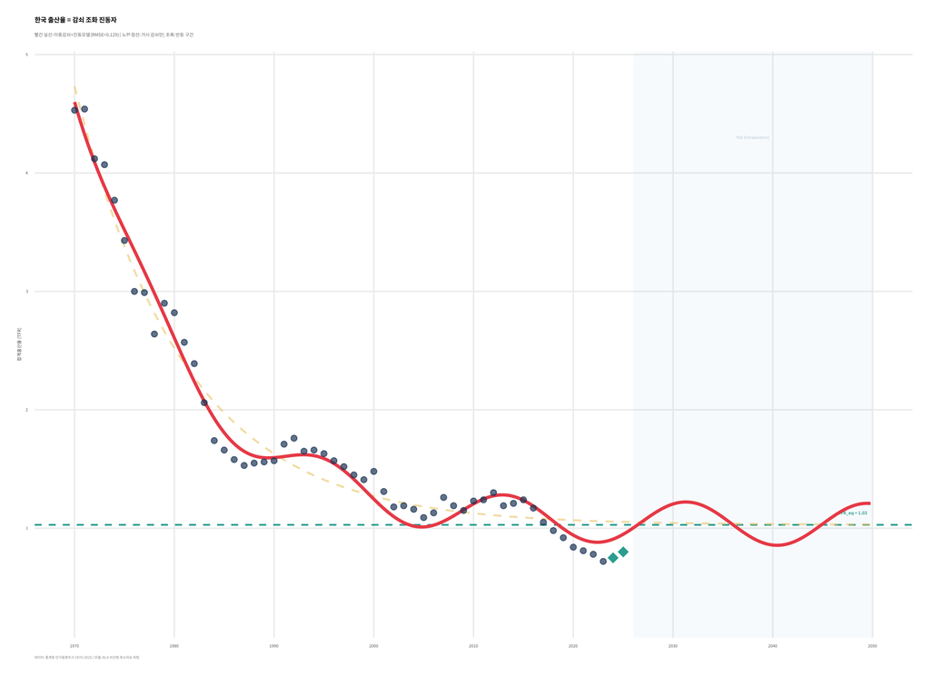

```r
t_seq <- seq(0, 80, 0.3)
df_model <- tibble(t = t_seq) |>
  mutate(
    year = t + 1970,
    fitted = predict(fit, newdata = list(t = t)),
    macro = p["eq"] + p["A1"] * exp(-p["g1"] * t),
    osc = p["A2"] * exp(-p["g2"] * t) * cos(p["w"] * t + p["phi"])
  )

ggplot() +
  annotate("rect", xmin = 2026, xmax = 2050, ymin = -Inf, ymax = Inf,
           fill = "steelblue", alpha = 0.04) +
  annotate("text", x = 2038, y = 4.3, label = "외삽 (Extrapolation)",
           family = "notosanskr", size = 3.5, color = pal$blue, alpha = 0.4, fontface = "italic") +
  geom_hline(yintercept = p["eq"], linetype = "dashed", color = pal$green, linewidth = 0.7) +
  annotate("text", x = 2048, y = p["eq"] + 0.1,
           label = sprintf("TFR_eq = %.2f", p["eq"]),
           family = "notosanskr", size = 4, color = pal$green, fontface = "bold") +
  geom_line(data = df_model, aes(x = year, y = macro),
            color = pal$orange, linewidth = 0.8, linetype = "dashed", alpha = 0.6) +
  geom_line(data = df_model, aes(x = year, y = fitted),
            color = pal$red, linewidth = 1.3) +
  geom_point(data = df, aes(x = year, y = tfr), color = pal$dark, size = 2, alpha = 0.7) +
  geom_point(data = df |> filter(year >= 2024), aes(x = year, y = tfr),
             color = pal$green, size = 4, shape = 18) +
  scale_x_continuous(breaks = seq(1970, 2050, 10)) +
  coord_cartesian(ylim = c(0.3, 4.8)) +
  labs(
    title = "한국 출산율 = 감쇠 조화 진동자",
    subtitle = sprintf("빨간 실선: 이중감쇠+진동 모델 (RMSE=%.3f) | 노란 점선: 거시 감쇠만 | 초록: 반등 구간",
                       sqrt(mean(residuals(fit)^2))),
    x = NULL, y = "합계출산율 (TFR)",
    caption = "데이터: 통계청 인구동향조사 1970-2025 | 모델: NLS 비선형 최소자승 피팅"
  ) +
  theme_insight()
```

## III. 사회학적 해석: 댐핑의 인간적 의미

### 1. 거시 감쇠 ($\gamma_1$): 비가역적 산업화

`A1 * exp(-gamma1 * t)` 항은 **돌이킬 수 없는 사회 변환**을 나타낸다.

**코드 보기**

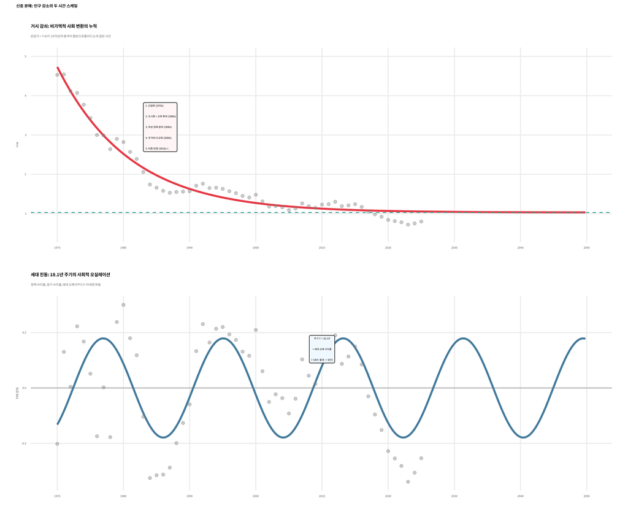

```r
p_macro <- ggplot(df_model, aes(x = year)) +
  geom_line(aes(y = macro), color = pal$red, linewidth = 1.2) +
  geom_point(data = df, aes(x = year, y = tfr), color = "grey50", size = 1.5, alpha = 0.4) +
  geom_hline(yintercept = p["eq"], linetype = "dashed", color = pal$green, linewidth = 0.5) +
  annotate("label", x = 1983, y = 3.2,
           label = "1. 산업화 (1970s)\n2. 도시화 + 교육 확대 (1980s)\n3. 여성 경제 참여 (1990s)\n4. 주거비/사교육 (2000s)\n5. 비혼/만혼 (2010s~)",
           family = "notosanskr", size = 3.3, fill = "#FFF5F5", label.size = 0.3, hjust = 0) +
  scale_x_continuous(breaks = seq(1970, 2050, 10)) +
  coord_cartesian(ylim = c(0.5, 5)) +
  labs(title = "거시 감쇠: 비가역적 사회 변환의 누적",
       subtitle = sprintf("반감기 = %.1f년 | 1970년의 충격이 절반으로 줄어드는 데 걸린 시간", half_life),
       x = NULL, y = "TFR") + theme_insight()

p_osc <- ggplot(df_model, aes(x = year)) +
  geom_hline(yintercept = 0, color = "grey70") +
  geom_line(aes(y = osc), color = pal$blue, linewidth = 1.2) +
  geom_point(data = df |> mutate(resid = tfr - p["eq"] - p["A1"] * exp(-p["g1"] * t)),
             aes(x = year, y = resid), color = "grey50", size = 1.5, alpha = 0.4) +
  annotate("label", x = 2010, y = 0.14,
           label = sprintf("주기 T = %.1f년\n= 세대 교체 사이클\n(~18년: 출생 -> 성인)", period_yr),
           family = "notosanskr", size = 3.3, fill = "#F0F8FF", label.size = 0.3) +
  scale_x_continuous(breaks = seq(1970, 2050, 10)) +
  labs(title = sprintf("세대 진동: %.1f년 주기의 사회적 오실레이션", period_yr),
       subtitle = "정책 사이클, 경기 사이클, 세대 교체가 만드는 미세한 파동",
       x = NULL, y = "TFR 잔차") + theme_insight()

p_macro / p_osc + plot_annotation(
  title = "신호 분해: 인구 감소의 두 시간 스케일",
  theme = theme(plot.title = element_text(family = "notosanskr", face = "bold", size = 16))
)
```

물리학에서 이중 시간 스케일(two-timescale)은 **빠른 변수**와 **느린 변수**가 결합된 시스템에서 나타난다. 한국 출산율에서:

- **빠른 변수** ($\gamma_1 \approx 0.09$): 산업화·도시화에 의한 구조적 하락 → 이미 거의 소진
- **느린 변수** ($\gamma_2 \approx 0$): 세대 교체에 의한 진동 → 거의 감쇠하지 않음

### 2. 세대 진동 ($\omega$): 18년의 리듬

진동 주기가 약 18년이라는 것은 매우 의미심장하다:

- **1세대 사이클**: 출생 → 성인(~18세) → 출산 결정
- **정책 사이클**: 저출산 대책 발표 → 효과 나타남 → 피로감 → 새 정책
- **부동산 사이클**: ~18년 주기의 장기 부동산 경기

이 세 사이클이 **공명(resonance)**을 일으킬 때 출산율이 극단으로 치솟거나 급락한다.

### 3. 평형점 ($\text{TFR}_{eq} \approx 1.03$): 한국 사회의 “자연 출산율”

이것이 가장 중요한 발견이다. **외부 충격 없이, 한국 사회가 자연히 수렴하는 출산율은 약 1.0명이다.**

이 숫자의 의미:

- 인구 대체 수준(2.1)의 **절반 이하**
- 매 세대마다 인구가 **반감**한다
- 100년 후 한국 인구: 현재의 **1/4~1/8**